# Bread dough experiment analysis

### Building and analyzing Completely Random Design (CRD) linear model with bread dough experiment

1. Gather some R packages

```r
## R package from the book
require(daewr)
## gmodels package that returns estimable contrasts
require(gmodels)
## nice visualization and summary tools for models, optional
require(jtools)
```

2. Check out the `bread` dataset. Note: only print the whole dataset in your write-up when you know the dataset is small, otherwise, something like `print(head(<your data>))` is more visually friendly.

```r
##
print(bread)
```

```
##    loaf time height
## 1     1   35   4.50
## 2     2   35   5.00
## 3     3   35   5.50
## 4     4   35   6.75
## 5     5   40   6.50
## 6     6   40   6.50
## 7     7   40  10.50
## 8     8   40   9.50
## 9     9   45   9.75
## 10   10   45   8.75
## 11   11   45   6.50
## 12   12   45   8.25
```

3. Build model using the R function `lm()`: treatment = time to rise, response variable = height of dough. Use `?lm` in R console to learn more about the function.

```r
mod0 <- lm(height ~ time, data = bread)

## take a look at summary stats to see effects estimates
summary( mod0 )
```

```
##
## Call:
## lm(formula = height ~ time, data = bread)
##
## Residuals:
##    Min     1Q Median     3Q    Max
## -1.812 -1.141  0.000  1.266  2.250
##
## Coefficients:
##             Estimate Std. Error t value Pr(>|t|)
## (Intercept)   5.4375     0.7655   7.104 5.65e-05 ***
## time40        2.8125     1.0825   2.598   0.0288 *
## time45        2.8750     1.0825   2.656   0.0262 *
## ---
## Signif. codes:  0 '***' 0.001 '**' 0.01 '*' 0.05 '.' 0.1 ' ' 1
##
## Residual standard error: 1.531 on 9 degrees of freedom
## Multiple R-squared:  0.5056, Adjusted R-squared:  0.3958
## F-statistic: 4.602 on 2 and 9 DF,  p-value: 0.042
```

```r
## you can also use the summ function from jtools for a more neat representation of the result

summ( mod0 )
```

| Observations | 12 |
| --- | --- |
| Dependent variable | height |
| Type | OLS linear regression |

| F(2,9) | 4.60 |
| --- | --- |
| R² | 0.51 |
| Adj. R² | 0.40 |

|  | Est. | S.E. | t val. | p |
| --- | --- | --- | --- | --- |
| (Intercept) | 5.44 | 0.77 | 7.10 | 0.00 |
| time40 | 2.81 | 1.08 | 2.60 | 0.03 |
| time45 | 2.88 | 1.08 | 2.66 | 0.03 |

Standard errors: OLS

Let’s start by creating the necessary matrices

```r
# y = response variable
y <- bread$height
# X = design matrix
X <- matrix(nrow = 12,ncol = 3)
X[,1] <- rep(1,12)
X[,2] <- c(rep(0,4),rep(1,4),rep(0,4))
X[,3] <- c(rep(0,8),rep(1,4))

XtX <- t(X)%*%X

XtX.inv <- solve(XtX)

beta.hat <- XtX.inv%*%t(X)%*%y
```

```r
# Z = alternative design matrix
Z <- matrix(nrow = 12,ncol = 4)
Z[,1] <- rep(1,12)
Z[,2] <- c(rep(1,4),rep(0,8))
Z[,3] <- c(rep(0,4),rep(1,4),rep(0,4))
Z[,4] <- c(rep(0,8),rep(1,4))

ZtZ <- t(Z)%*%Z
```

6. Alternatively, we can estimate the contrasts between effects $\tau_i$

```r
t1.t2<-fit.contrast(model = mod0, 'time', c(1,-1,0))
t1.t3<-fit.contrast(model = mod0, 'time', c(1,0,-1))
```

7. *Hypothesis testing* , we now want to test the hypothesis $H_0 : \mu_1 = \mu_2 = \cdots = \mu_t$ vs the alternative, which is unequal effect for any pair. F test looks at the ratio of variation from two different sources. In our case, we are interested in treatment variation vs model variation. In R, we can use `lm()` to do ANOVA, but `aov` is a simple way that is sometimes preferred.

```r
mod1 <- aov(height~time, data = bread)
print(summary(mod1))
```

```
##             Df Sum Sq Mean Sq F value Pr(>F)
## time         2  21.57  10.786   4.602  0.042 *
## Residuals    9  21.09   2.344
## ---
## Signif. codes:  0 '***' 0.001 '**' 0.01 '*' 0.05 '.' 0.1 ' ' 1
```

In the F-test above, assuming a significance level $\alpha = 0.5$, we should reject $H_0.$

8. *Model assumption check* - how valid are the results of our analysis so far? One way to find out is the verify that the model assumptions are met, which we can show in R using the following commands:

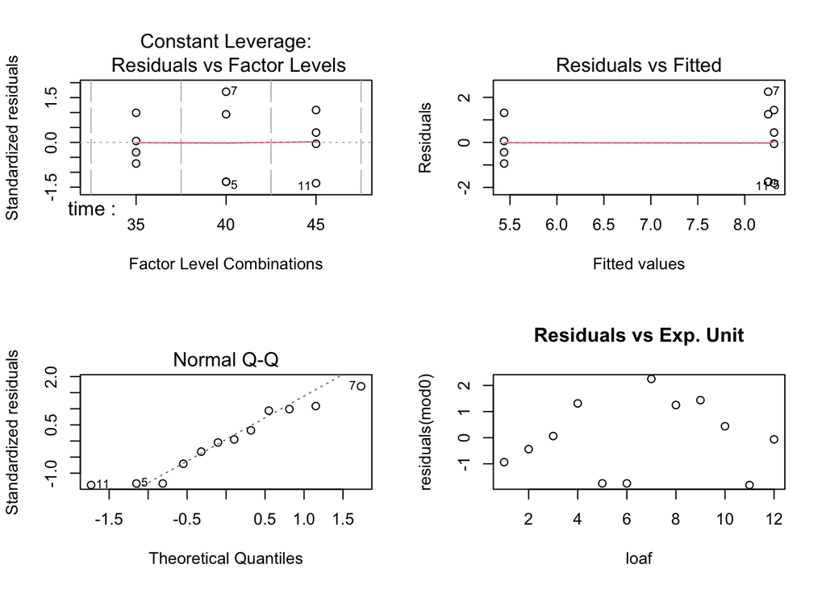

```r
# generate 2 by 2 canvas for plots
par( mfrow = c(2,2))
plot(mod0, which = 5)
plot(mod0, which = 1)
plot(mod0, which = 2)
plot(residuals(mod0)~loaf, main = 'Residuals vs Exp. Unit', data = bread)
```